# Explore and Summarize Data of red wine

Fahad Alanazi

January 20th, 2019

========================================================

## Introduction

The dataset is a tidy csv file containing 1599 observations and have 12 variables associated to them. I will perform Exploratory Data Analysis (EDA) on a data set which contains red wines with variables on the chemical properties of the wine. I will use visual methods univariate, bivariate and multivariate plots to summarise the main charecteristics of the data set. Main goal here is to find what factors contribute to quality of a red wine .

```
## 'data.frame':    1599 obs. of  12 variables:
##  $ fixed.acidity       : num  7.4 7.8 7.8 11.2 7.4 7.4 7.9 7.3 7.8 7.5 ...
##  $ volatile.acidity    : num  0.7 0.88 0.76 0.28 0.7 0.66 0.6 0.65 0.58 0.5 ...
##  $ citric.acid         : num  0 0 0.04 0.56 0 0 0.06 0 0.02 0.36 ...
##  $ residual.sugar      : num  1.9 2.6 2.3 1.9 1.9 1.8 1.6 1.2 2 6.1 ...
##  $ chlorides           : num  0.076 0.098 0.092 0.075 0.076 0.075 0.069 0.065 0.073 0.071 ...
##  $ free.sulfur.dioxide : num  11 25 15 17 11 13 15 15 9 17 ...
##  $ total.sulfur.dioxide: num  34 67 54 60 34 40 59 21 18 102 ...
##  $ density             : num  0.998 0.997 0.997 0.998 0.998 ...
##  $ pH                  : num  3.51 3.2 3.26 3.16 3.51 3.51 3.3 3.39 3.36 3.35 ...
##  $ sulphates           : num  0.56 0.68 0.65 0.58 0.56 0.56 0.46 0.47 0.57 0.8 ...
##  $ alcohol             : num  9.4 9.8 9.8 9.8 9.4 9.4 9.4 10 9.5 10.5 ...
##  $ quality             : Ord.factor w/ 6 levels "3"<"4"<"5"<"6"<..: 3 3 3 4 3 3 3 5 5 3 ...
```

# Univariate Plots Section

```
##  fixed.acidity   volatile.acidity  citric.acid    residual.sugar
##  Min.   : 4.60   Min.   :0.1200   Min.   :0.000   Min.   : 0.900
##  1st Qu.: 7.10   1st Qu.:0.3900   1st Qu.:0.090   1st Qu.: 1.900
##  Median : 7.90   Median :0.5200   Median :0.260   Median : 2.200
##  Mean   : 8.32   Mean   :0.5278   Mean   :0.271   Mean   : 2.539
##  3rd Qu.: 9.20   3rd Qu.:0.6400   3rd Qu.:0.420   3rd Qu.: 2.600
##  Max.   :15.90   Max.   :1.5800   Max.   :1.000   Max.   :15.500
##    chlorides       free.sulfur.dioxide total.sulfur.dioxide
##  Min.   :0.01200   Min.   : 1.00       Min.   :  6.00
##  1st Qu.:0.07000   1st Qu.: 7.00       1st Qu.: 22.00
##  Median :0.07900   Median :14.00       Median : 38.00
##  Mean   :0.08747   Mean   :15.87       Mean   : 46.47
##  3rd Qu.:0.09000   3rd Qu.:21.00       3rd Qu.: 62.00
##  Max.   :0.61100   Max.   :72.00       Max.   :289.00
##     density             pH          sulphates         alcohol      quality
##  Min.   :0.9901   Min.   :2.740   Min.   :0.3300   Min.   : 8.40   3: 10
##  1st Qu.:0.9956   1st Qu.:3.210   1st Qu.:0.5500   1st Qu.: 9.50   4: 53
##  Median :0.9968   Median :3.310   Median :0.6200   Median :10.20   5:681
##  Mean   :0.9967   Mean   :3.311   Mean   :0.6581   Mean   :10.42   6:638
##  3rd Qu.:0.9978   3rd Qu.:3.400   3rd Qu.:0.7300   3rd Qu.:11.10   7:199
##  Max.   :1.0037   Max.   :4.010   Max.   :2.0000   Max.   :14.90   8: 18
```

# Histogram - Quality

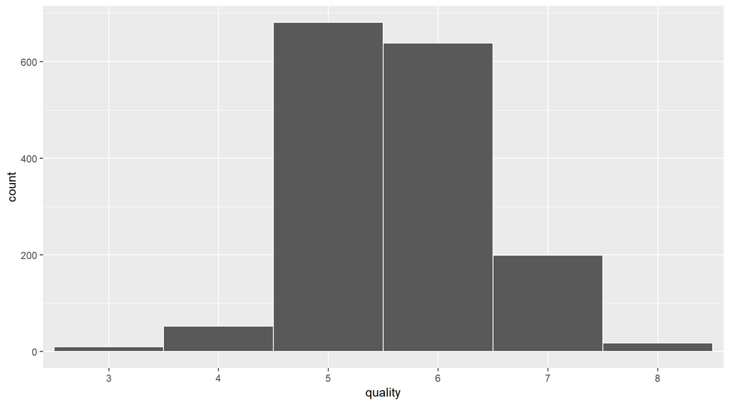

```
##   3   4   5   6   7   8
##  10  53 681 638 199  18
```

The highest aveage quality is level 5 .

# Histogram - fixed acidity

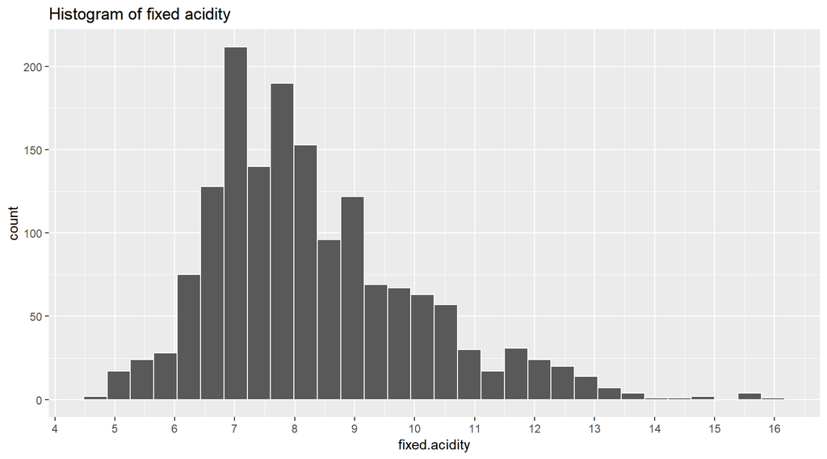

```
##    Min. 1st Qu.  Median    Mean 3rd Qu.    Max.
##    4.60    7.10    7.90    8.32    9.20   15.90
```

The median fixed acidity in the wines present in the dataset is 7.90 .

# Histogram - volatile acidity

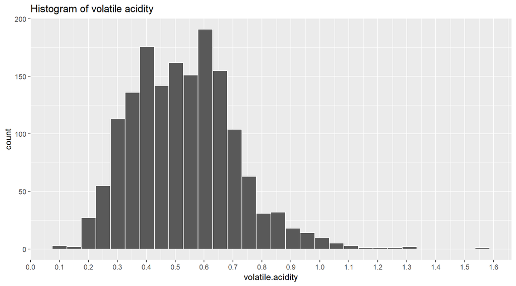

```
##    Min. 1st Qu.  Median    Mean 3rd Qu.    Max.
##  0.1200  0.3900  0.5200  0.5278  0.6400  1.5800
```

The distribution of volatile acidity is non-symmetric and bimodal with two peaks at 0.4 and 0.6. The median value is 0.52. Most observations fall in the range 0.39 - 0.64 and outliers on the higher end of the scale are visible.

# Histogram - citric acid

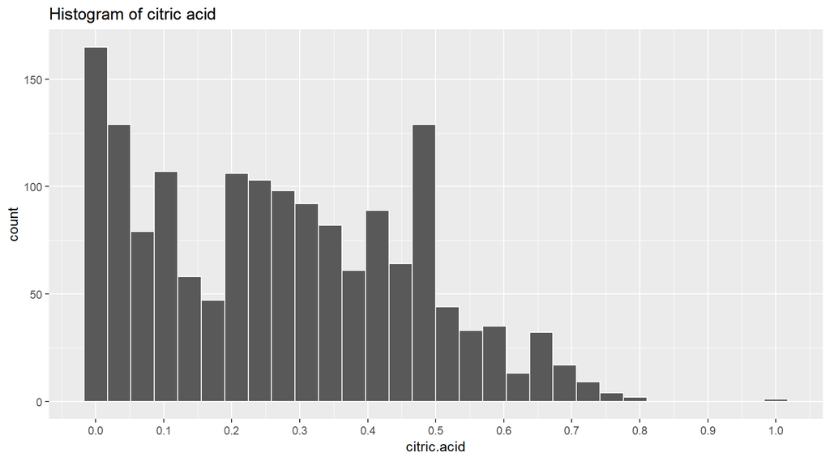

```
##    Min. 1st Qu.  Median    Mean 3rd Qu.    Max.
##   0.000   0.090   0.260   0.271   0.420   1.000
```

# Histogram - residual sugar

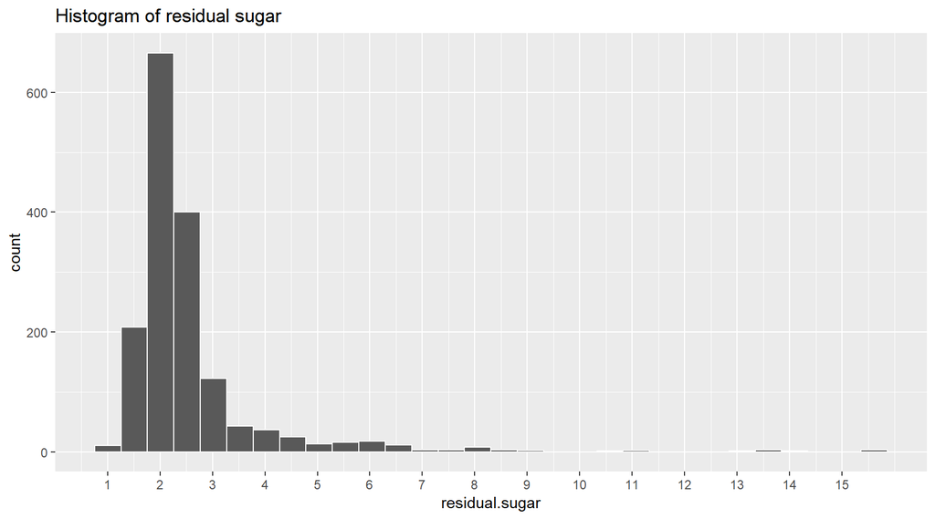

```
##    Min. 1st Qu.  Median    Mean 3rd Qu.    Max.
##   0.900   1.900   2.200   2.539   2.600  15.500
```

The distribution of residual sugar has a median value of 2.2

# Histogram - chlorides

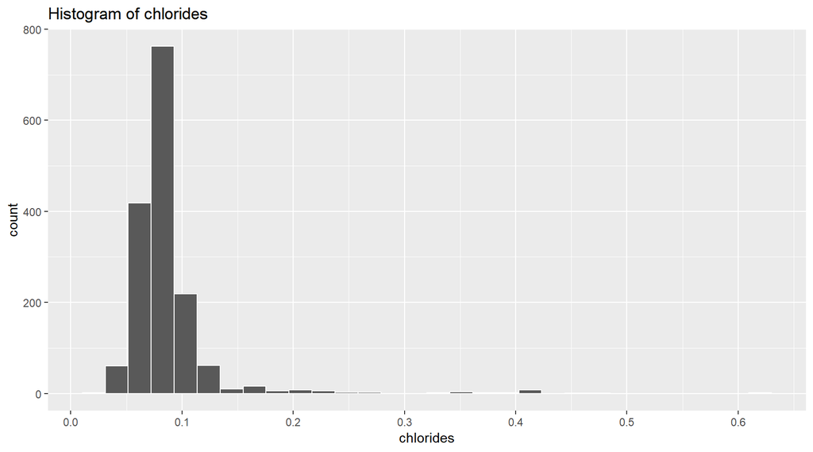

```
##    Min. 1st Qu.  Median    Mean 3rd Qu.    Max.
## 0.01200 0.07000 0.07900 0.08747 0.09000 0.61100
```

the median value 0.07900 . The distribution with looks normal around its main peak but has a very long right tail, with small counts of wines with values until 0.611 .

# Histogram - free sulfur dioxide

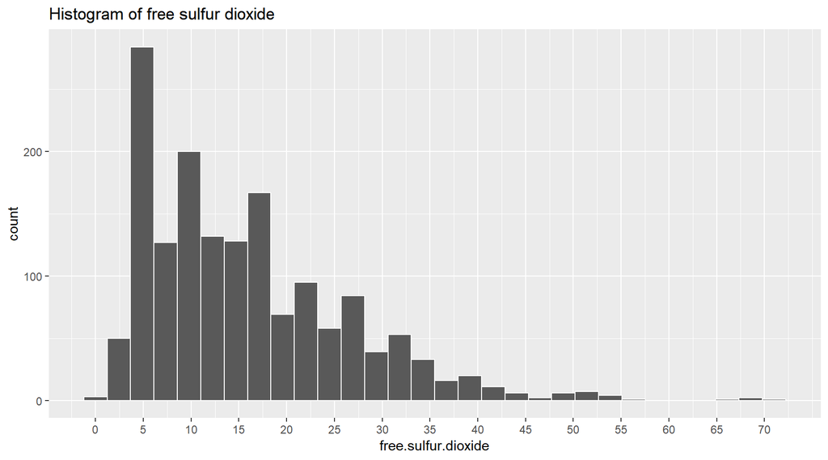

```
##    Min. 1st Qu.  Median    Mean 3rd Qu.    Max.
##    1.00    7.00   14.00   15.87   21.00   72.00
```

The distribution of free sulfur dioxide concentrations is right skewed. The median value is 14.

# Histogram - total sulfur dioxide

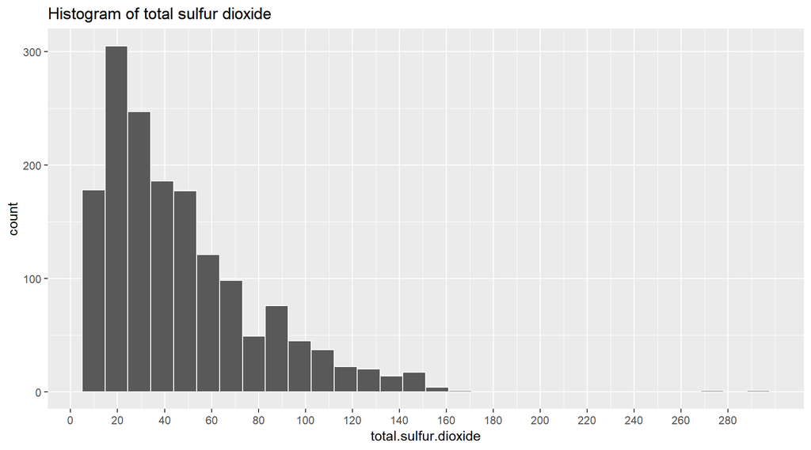

```
##    Min. 1st Qu.  Median    Mean 3rd Qu.    Max.
##    6.00   22.00   38.00   46.47   62.00  289.00
```

The distribution of total sulfur dioxide is right skewed with a median value of 38 .

# Histogram - density

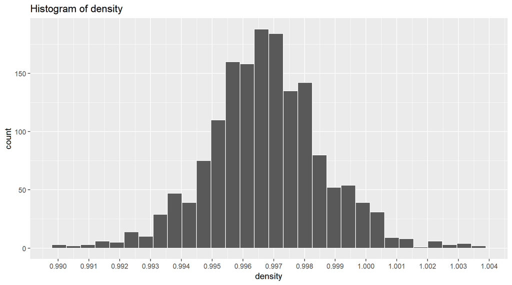

```
##    Min. 1st Qu.  Median    Mean 3rd Qu.    Max.
##  0.9901  0.9956  0.9968  0.9967  0.9978  1.0037
```

# Histogram - PH

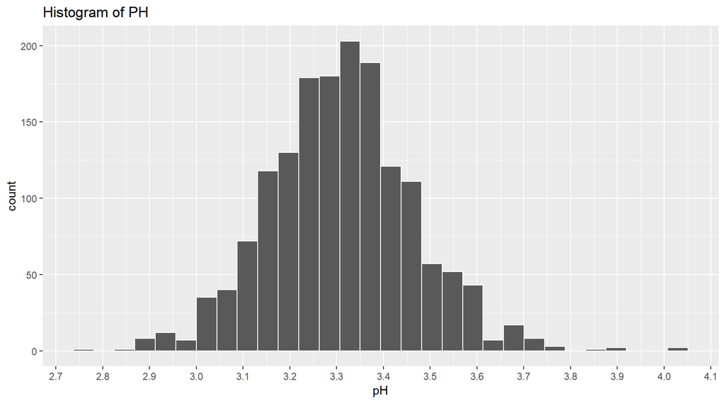

```
##    Min. 1st Qu.  Median    Mean 3rd Qu.    Max.
##   2.740   3.210   3.310   3.311   3.400   4.010
```

The median value is 3.31, and most wines have a pH between 3.21 and 3.4.

# Histogram - sulphates

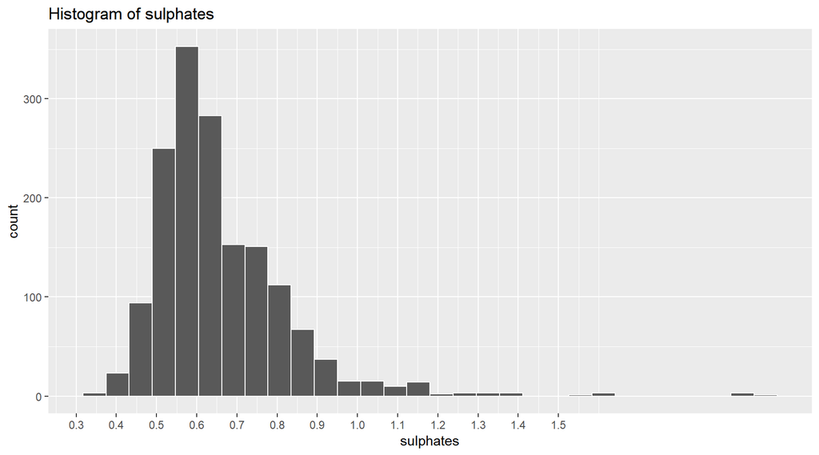

```
##    Min. 1st Qu.  Median    Mean 3rd Qu.    Max.
##  0.3300  0.5500  0.6200  0.6581  0.7300  2.0000
```

The distribution of sulphates is slightly right skewed, most wines have a concentration between 0.55 and 0.73.

# Histogram - alcohol

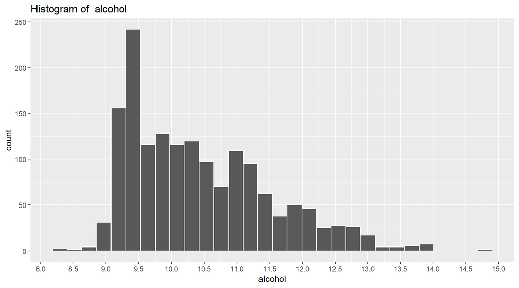

```
##    Min. 1st Qu.  Median    Mean 3rd Qu.    Max.
##    8.40    9.50   10.20   10.42   11.10   14.90
```

The alcohol concentration distribution is right skewed. The highest peak of the distribution is at 9.50 % alcohol and the median value is 10.20%. The maximum amount of alcohol present in the dataset is 14.90.

## Univariate Analysis

### What is the structure of your dataset?

The dataset has 12 variables regarding 1599 observations .

### What is/are the main feature(s) of interest in your dataset?

The main feature of interest is the quality .

### What other features in the dataset do you think will help support your into your feature(s) of interest?

i will see if these variables play a role in quality of wine or not

### Did you create any new variables from existing variables in the dataset?

NO

### Of the features you investigated, were there any unusual distributions? you perform any operations on the data to tidy, adjust, or change the form of the data? If so, why did you do this?

There was no usual distribution so don’t need adjust or change the data .

# Quality vs density

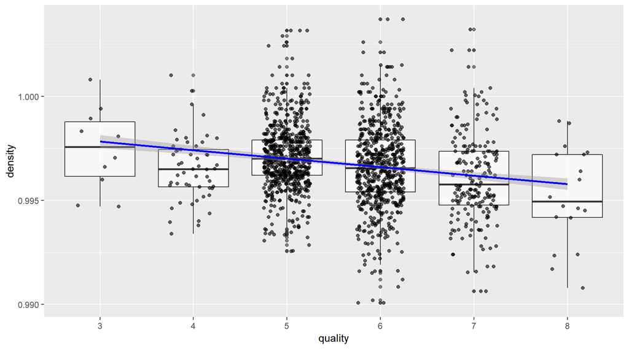

We can see that there are some outliers at quality 5, 6 and 7.

# Quality vs volatile acidity

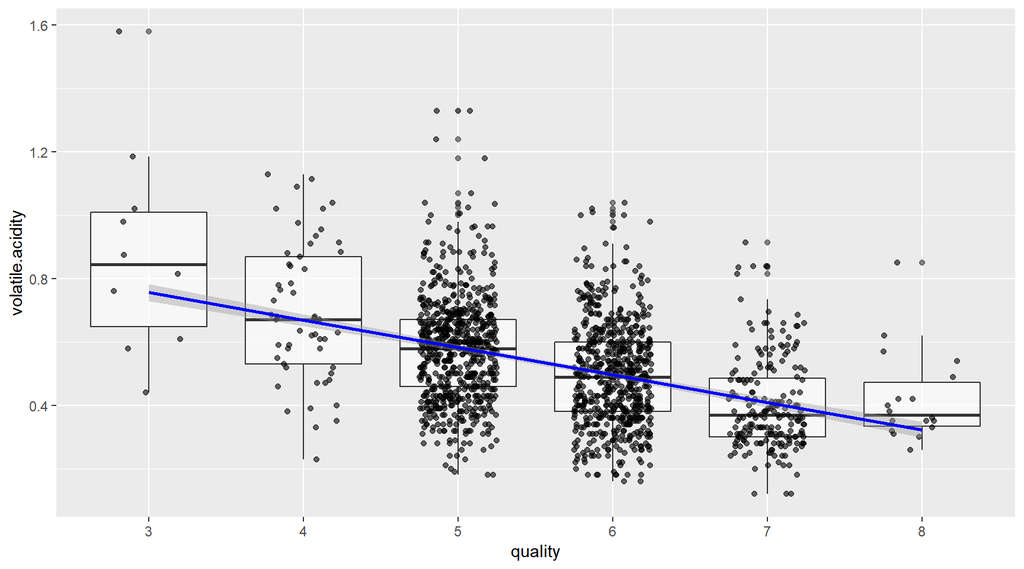

Volatile acid seems to have a negative impact on the quality of the wine. As volatile acid level goes up, the quality of the wine degrades.

# Quality vs alcohol

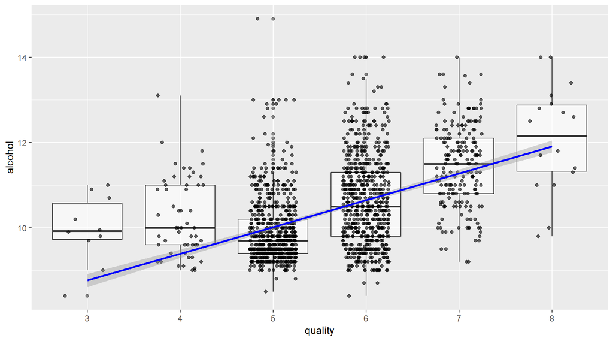

We can see that there are some outliers at quality 3, 5 and 6.

# Quality vs free sulfur dioxide

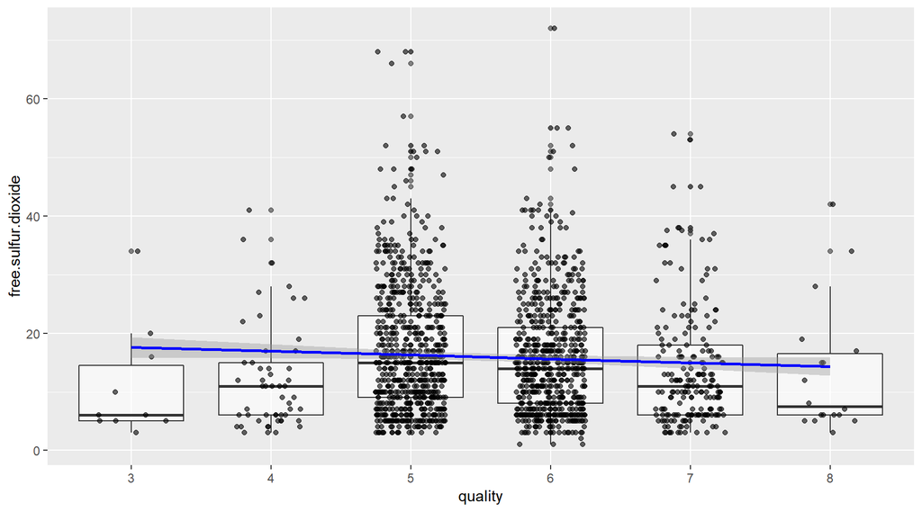

We can see that there are outliers all quality level.

# Quality vs total sulfur dioxide

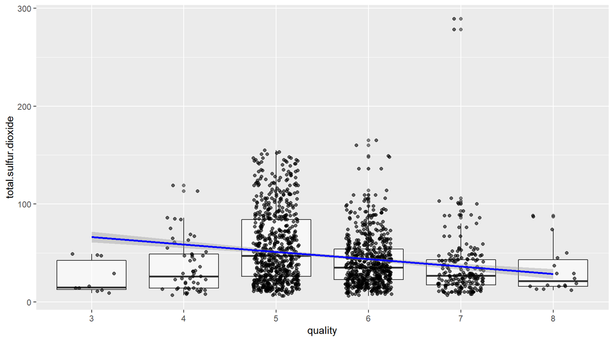

We can see that there are some outliers at quality 4, 6, 7and 8.

# Quality vs residual sugar

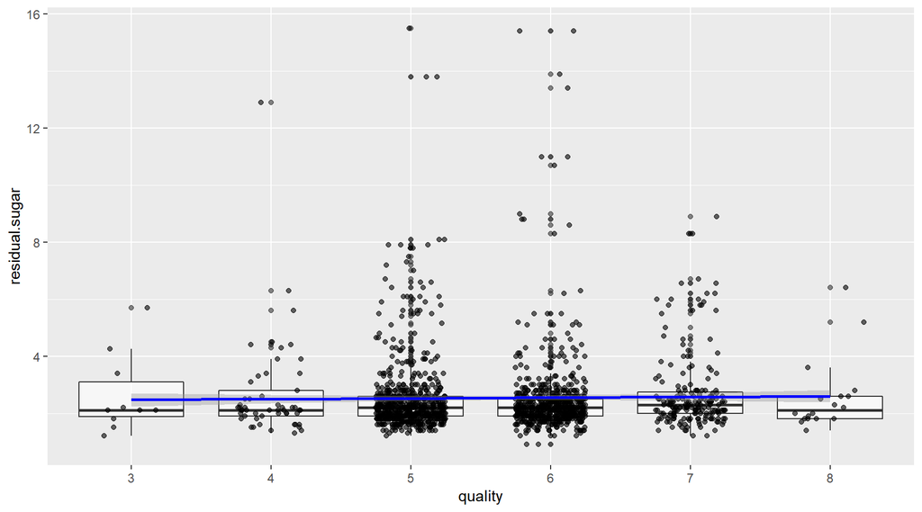

We can notice the median of quality levels almost equal.

# fixed_acidity vs pH

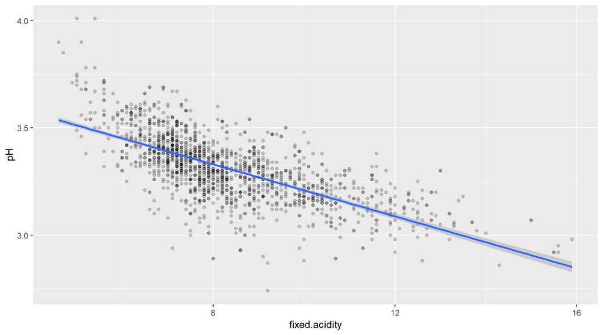

The pH increases with the lower amount of acids. Fixed acidity accounts for most acids present in the wine.

# fixed_acidity vs density

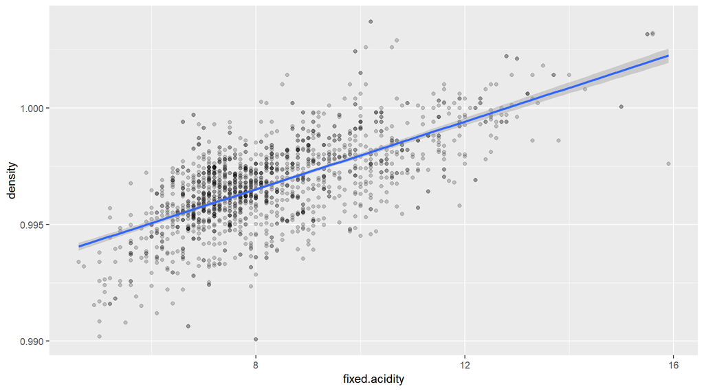

The fixed acidity increases with density.

## Bivariate Analysis

### What was the strongest relationship you found?

The strongest correlation for quality was that of alcohol .